# Traffic Predictions

Data 621 Final Project

Tommy Jenkins, Violeta Stoyanova, Todd Weigel, Peter Kowalchuk, Eleanor R-Secoquian, Anthony Pagan

20-Dec-2019

### Abstract

The purpose of this project is to build various models in an attempt to predict the trip duration of yellow taxis in New York City.

### Introduction

“The Partnership for New York City's one-page study asserted that “excess congestion” deprives the five boroughs and the suburbs of Long Island, Westchester and Rockland counties and northern New Jersey $20 billion annually,” according to Crain’s. Moreover, emergency services reports life or death consequences based on NYC traffic conditions, according to multiple sources. We seek to analyze publicly accessible datasets in the service of better understanding the factors that influence traffic as encapsulated in the Kaggle competition: New York City Taxi Trip Duration . In a recent article, Emil Skandul, writing for City and State NY, cited the importance of Mayor De Blasio hiring a technologically savvy commissioner to lead the Taxi and Limousine Commission to rival Lyft and Uber. In all of these regards, we believe being able to predict traffic through the proxy of taxi trip duration can be highly relevant to the welfare of the NYC population.

### Method

We will consider following the competition evaluation metrics and results format, only in cases where it fully agrees with the recommendations of our DATA 621 coursework.

### Data Exploration

The features we will initially consider can be found under the data tab in the competition page and we may choose to augment the data with information such as weather.

**File descriptions**

● train.csv - the training set (contains 1458644 trip records)

● test.csv - the testing set (contains 625134 trip records)

**Data fields**

● id - a unique identifier for each trip

● vendor_id - a code indicating the provider associated with the trip record

● pickup_datetime - date and time when the meter was engaged

● dropoff_datetime - date and time when the meter was disengaged

● passenger_count - the number of passengers in the vehicle (driver entered value)

● pickup_longitude - the longitude where the meter was engaged

● pickup_latitude - the latitude where the meter was engaged

● dropoff_longitude - the longitude where the meter was disengaged

● dropoff_latitude - the latitude where the meter was disengaged

● store_and_fwd_flag - This flag indicates whether the trip record was held in vehicle memory before sending to the vendor because the vehicle did not have a connection to the server - Y=store and forward; N=not a store and forward trip

● trip_duration - duration of the trip in seconds

### Visuals

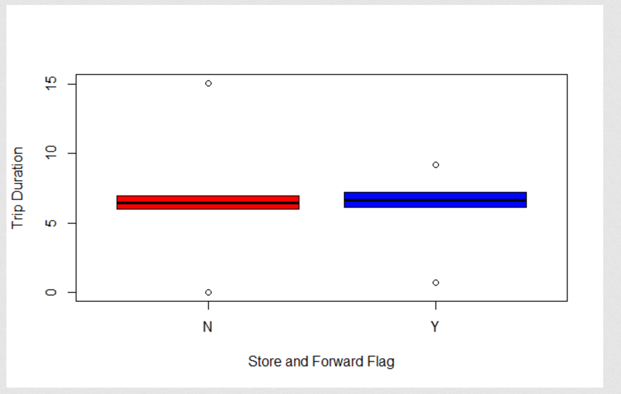

### Visuals

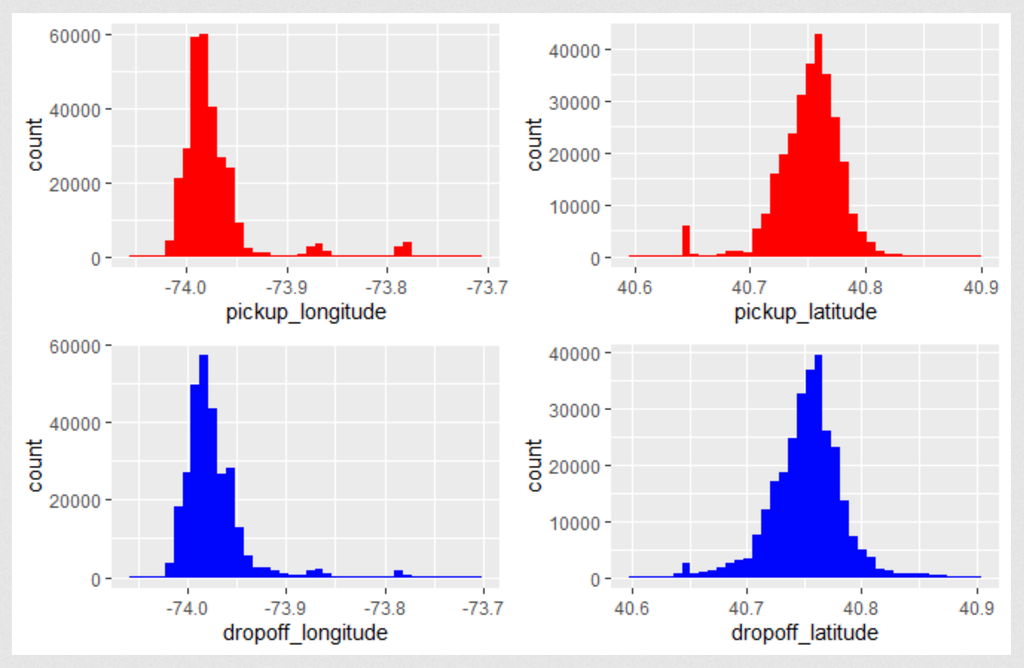

### Visuals

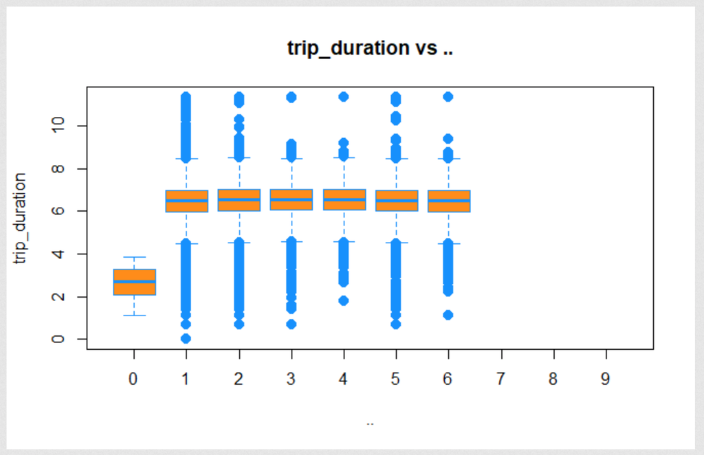

### Visuals

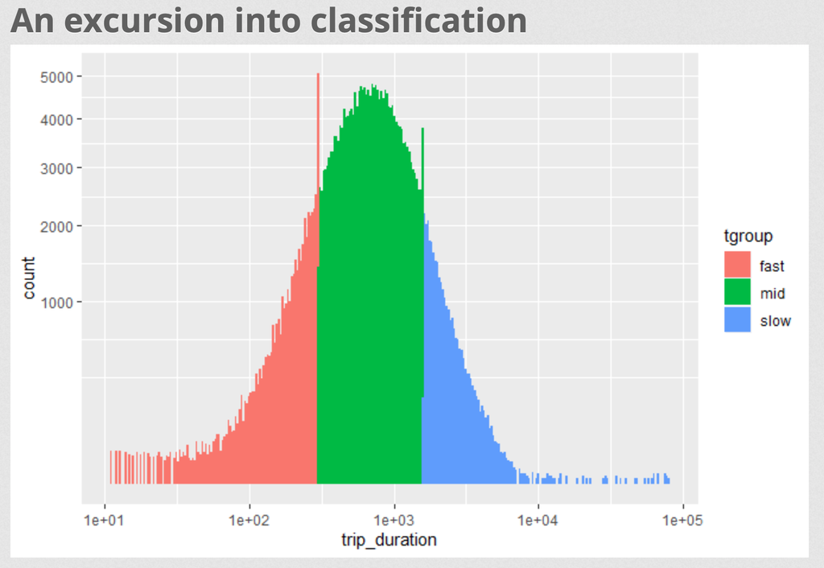

### Visuals

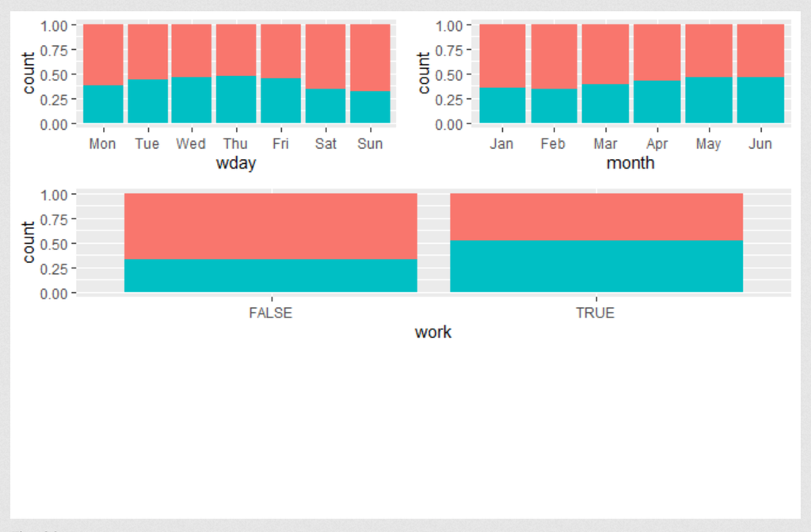

### Visuals

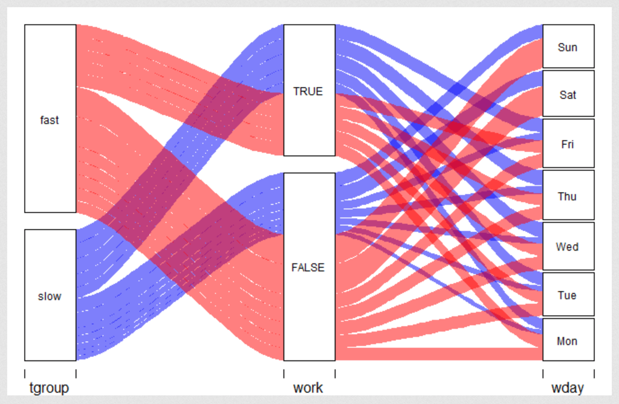

### Visuals

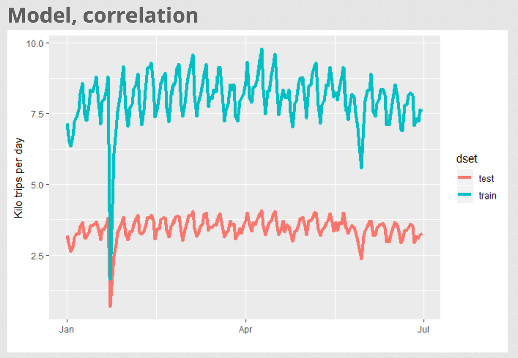

### Visuals

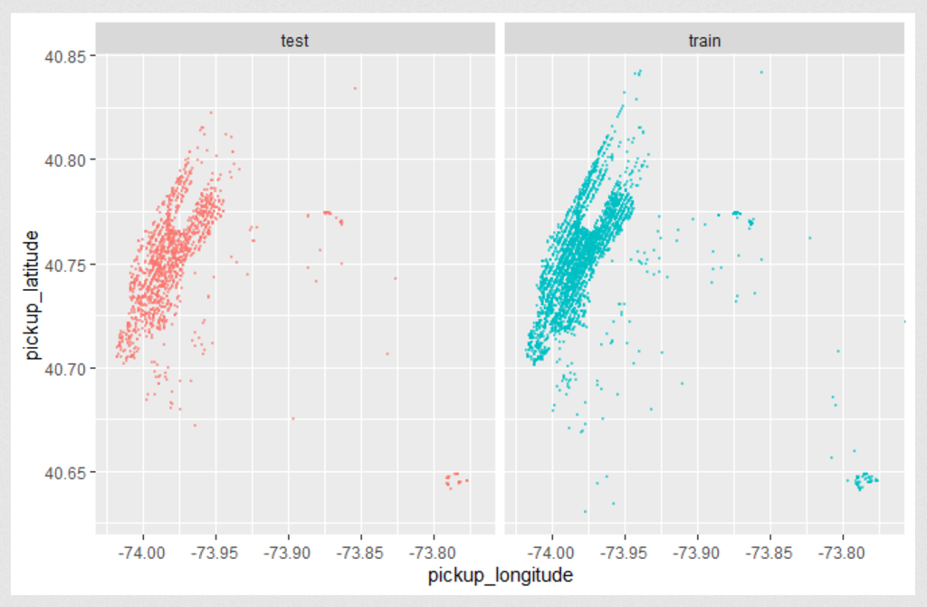

### Selection Model Result

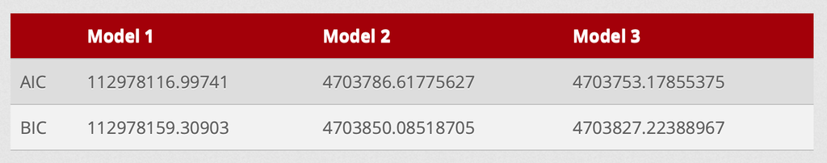

### Conclusion

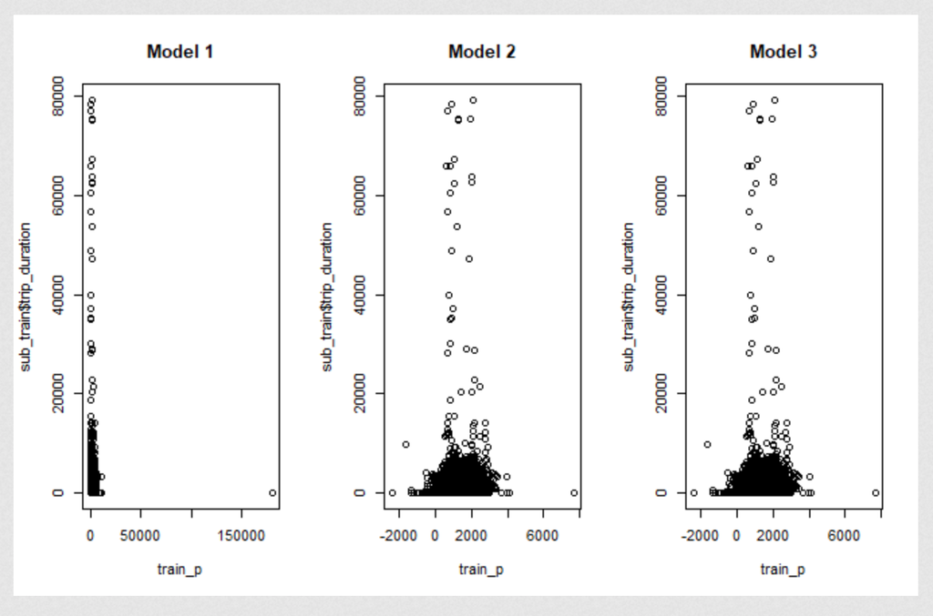